Álgebra Linear com Python

# Aplicações de Matrizes em Situações do Dia a Dia

#### Vamos apresentar dois problemas rotineiros: um sobre um planejamento de atividades físicas e outro sobre planejamento financeiro de uma empresa. Ambos podem ser solucionados utilizando conhecimentos sobre matrizes em Álgebra Linear.

##### Leon, Steven J., 1943 - Álgebra Linear com Aplicações/ Steven J. Leon; tradução Valéria de Magalhães Iório - [reimpr]. Rio de Janeiro: LTC, 2008.

### Aplicação 1: Queimando calorias

Alysson pesa 81 quilos. Ele quer perder peso por meio de um progama de dieta e exercícios. Após consultar a **tabela 1**, ele monta o programa de exercícios na **tabela 2**. quantas calorias ele vai queimar por dia se seguir esse progama?

#### Tabela 1. Calorias Queimadas por Hora

- **Atividades Esportivas**

| **Peso** | **Andar a 3km/h** | **Correr a 9km/h** | **Andar de bicicleta a 9km/h** | **Jogar Tênis(Moderado)** |
| --- | --- | --- | --- | --- |
| 69 | 213 | 651 | 304 | 420 |
| 73 | 225 | 688 | 321 | 441 |
| 77 | 237 | 726 | 338 | 468 |
| 81 | 249 | 764 | 356 | 492 |

```python
# importando a biblioteca numpy do Python
import numpy as np
# importando a biblioteca de funções do Python matplotlib
import matplotlib
import matplotlib.pyplot as plt
%matplotlib inline
```

```python
# definindo a matriz A a partir da tabela 1
A = np.array([[213, 651, 304, 420],
              [225, 688, 321, 441],
              [237, 726, 338, 468],
              [249, 764, 356, 492]])
```

```python
# imprimindo a matriz A
print("A matriz A é\n\n", A)
```

```
A matriz A é

 [[213 651 304 420]
 [225 688 321 441]
 [237 726 338 468]
 [249 764 356 492]]
```

#### Tabela 2. Horas por Dia para Cada Atividade

- **Programa de Exercícios**

| **Dias da Semana** | **Andar** | **Correr** | **Andar de Bicicleta** | **Jogar Tênis** |
| --- | --- | --- | --- | --- |
| Segunda-feira | 1.0 | 0.0 | 1.0 | 0.0 |
| Terça-feira | 0.0 | 0.0 | 0.0 | 2.0 |
| Quarta-feira | 0.4 | 0.5 | 0.0 | 0.0 |
| Quinta-feira | 0.0 | 0.0 | 0.5 | 2.0 |
| Sexta-feira | 0.4 | 0.5 | 0.0 | 0.0 |

```python
# definindo a matriz B a partir da tabela 2
B = np.array([[1.0, 0.0, 1.0, 0.0],
              [0.0, 0.0, 0.0, 2.0],
              [0.4, 0.5, 0.0, 0.0],
              [0.0, 0.0, 0.5, 2.0],
              [0.4, 0.5, 0.0, 0.0]])
```

```python
# imprimindo a matriz B
print("A matriz B é\n\n", B)
```

```
A matriz B é

 [[1.  0.  1.  0. ]
 [0.  0.  0.  2. ]
 [0.4 0.5 0.  0. ]
 [0.  0.  0.5 2. ]
 [0.4 0.5 0.  0. ]]
```

###### Solução:

A informação pertinente para Alysson está localizada na quarta linha da **matriz A**, pois são os dados referentes a quem pesa 81 quilos.

Vamos criar uma nova matriz **x** do tipo **vetor-coluna** baseado nos dados contidos na 4º linha da **matriz A**.

```python
# x recebe a quarta linha de A
x = A[3]
```

```python
# x é transposta para se tornar um vetor-coluna
x = np.transpose(x)
```

Para resolver o problema, basta multiplicar a matriz $B_{5_{x}4}$ pela matriz $x_{4_{x}1}$.

```python
# realizando a multiplicação da matriz B com a matriz x
Calorias = np.dot(B,x)
```

```python
# imprimindo a matriz de calorias gastas por semana
print("A matriz de calorias é:\n\n", Calorias)
```

```
A matriz de calorias é:

 [ 605.   984.   481.6 1162.   481.6]
```

```python
# esquematizando as etiquetas do gráfico no eixo x
DiasdaSemana = ['Segunda-feira', 'Terça-feira', 'Quarta-feira', 'Quinta-feira', 'Sexta-feira']
```

Dessa forma, vemos que Alysson, seguindo sua rotina de atividades físicas, queimara as respectivas calorias durante a semana:

| **Dias da Semana** | **Calorias Gastas** |
| --- | --- |
| Segunda-feira | 605.0 calorias |
| Terça-feira | 984.0 calorias |
| Quarta-feira | 481.6 calorias |
| Quinta-feira | 1162.0 calorias |
| Sexta-feira | 481.6 calorias |

Assim, podemos ter o seguinte gráfico:

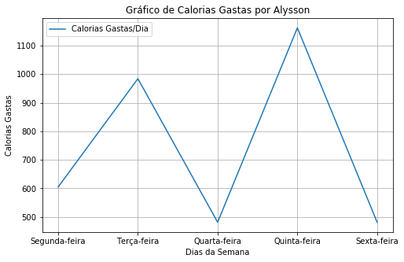

```python
# definindo as dimensões do gráfico
plt.figure(figsize=(8,5))
# definindo a legenda do eixo x
plt.xlabel('Dias da Semana')
# definindo as legendas do eixo y
plt.ylabel('Calorias Gastas')
# plotando o gráfico e definindo uma legenda
plt.plot(DiasdaSemana, Calorias, label = 'Calorias Gastas/Dia')
# chamando a legenda para ser exposta no gráfico
plt.legend()
# definindo um input diferente de 0 para entrada verdadeira na grade do gráfico
plt.grid(True)
# definindo o título do gráfico
plt.title('Gráfico de Calorias Gastas por Alysson')
```

### Aplicação 2: Gestão Financeira de uma Empresa

Uma empresa fabrica três produtos. Suas despesas de produção estão divididas em três categorias. Em cada uma dessas categorias, faz-se uma estimativa do custo de produção de um único exemplar de cada produto. Faz-se, também, uma estimativa da quantidade de cada produto a ser fabricado por trimestre. Essas estimativas são dadas na **tabela 3** e na **tabela 4**. A empresa gostaria de apresentar a seus acionistas uma única tabela mostrando o custo total por **trimestre** de cada uma das três categorias: **matéria- prima**, **pessoal** e **despesas gerais**.

#### Tabela 3. Custo de Produção por Item (em reais)

| **Gastos** | **Produto A** | **Produto B** | **Produto C** |
| --- | --- | --- | --- |
| Matéria-prima | 0.10 | 0.30 | 0.15 |
| Pessoal | 0.30 | 0.40 | 0.25 |
| Despesas-gerais | 0.10 | 0.20 | 0.15 |

```python
# definindo a matriz C baseada na tabela 3
C = np.array([[0.10, 0.30, 0.15],
              [0.30, 0.40, 0.25],
              [0.10, 0.20, 0.15]])
```

```python
# imprimindo a matriz C
print("A matriz C é:\n\n", C)
```

```
A matriz C é:

 [[0.1  0.3  0.15]
 [0.3  0.4  0.25]
 [0.1  0.2  0.15]]
```

###### Tabela 4. Quantidade Produzida por Trimestre

| **Produto** | **Verão** | **Outono** | **Inverno** | **Primavera** |
| --- | --- | --- | --- | --- |
| A | 4000 | 4500 | 4500 | 4000 |
| B | 2000 | 2600 | 2400 | 2200 |
| C | 5800 | 6200 | 6000 | 6000 |

```python
# definindo a matriz D baseado na tabela 4
D = np.array([[4000, 4500, 4500, 4000],
              [2000, 2600, 2400, 2200],
              [5800, 6200, 6000, 6000]])
```

```python
print("A matriz D é:\n\n", D)
```

```
A matriz D é:

 [[4000 4500 4500 4000]
 [2000 2600 2400 2200]
 [5800 6200 6000 6000]]
```

Se fizermos o produto **CD**, teremos o custo de cada categoria por trimestre.

```python
# realizando a multiplicação da matriz C com a matriz D
Custos = np.dot(C, D)
```

```python
# imprime a matriz de custos por trimeste em cada categoria, em reais
print("A matriz de Custos é:\n\n", Custos)
```

```
A matriz de Custos é:

 [[1870. 2160. 2070. 1960.]
 [3450. 3940. 3810. 3580.]
 [1670. 1900. 1830. 1740.]]
```

| **Custos de cada Categoria por Trimeste** | **Verão** | **Outono** | **Inverno** | **Primavera** |
| --- | --- | --- | --- | --- |
| Matéria-prima | 1870 | 2160 | 2070 | 1960 |
| Pessoal | 3450 | 3940 | 3810 | 3580 |
| Despesas Gerais | 1670 | 1900 | 1830 | 1740 |

```python
# esquematizando as etiquetas do gráfico no eixo x
Trimestres = ['Verão', 'Outono', 'Inverno', 'Primaveira']
# definindo os valores gastos apenas na categoria Matéria-Prima
MateriaPrima = Custos[0]
# definindo os valores gastos apenas na categoria Pessoal
Pessoal = Custos[1]
# definindo os valores gastos apenas na categoria Despesas Gerais
DespesasGerais = Custos[2]
```

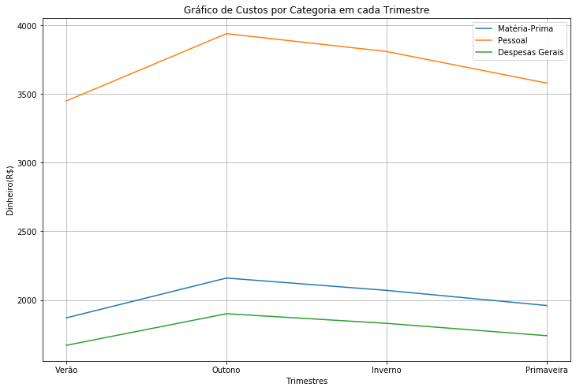

```python
# definindo as dimensões do gráfico
plt.figure(figsize=(12,8))
# definindo a legenda do eixo x
plt.xlabel('Trimestres')
# definindo a legenda do eixo y
plt.ylabel('Dinheiro(R$)')
# plotando o gráfico para a categoria Matéria-Prima, com sua respectiva legenda
plt.plot(Trimestres, MateriaPrima, label = 'Matéria-Prima')
# plotando o gráfico para a categoria Pessoal, com sua respectiva legenda
plt.plot(Trimestres, Pessoal, label = 'Pessoal')
# plotando o gráfico para a categoria Despesas Gerais, com sua respectiva legenda
plt.plot(Trimestres, DespesasGerais, label = 'Despesas Gerais')
# chamando a legenda para ser exposta no gráfico
plt.legend()
# definindo um input diferente de 0 para entrada verdadeira na grade do gráfico
plt.grid(True)
# definindo o título do gráfico
plt.title('Gráfico de Custos por Categoria em cada Trimestre')
```

Desse modo, observe que a álgebra linear pode estar presente em diversas situações do nosso dia a dia até situações mais complexas de engenharia. Por esse motivo, a disciplina deve ser levada a sério e merece ser estudada com um maior grau de profundidade por parte dos estudantes.

### Alguma Dúvida? Entre em Contato Comigo:

- Me envie um e-mail;